# Homework 5 Mechanics

Health plans use many tools to try to control the cost of prescription medicines. For older drugs, generic substitutes that are equivalent to name-brand drugs are sometimes available at a lower cost. Another tool that may lower costs is restricting the drugs that physicians may prescribe. For example, if several similar drugs are available for treating the same symptoms, a health plan may require physicians to prescribe only a few of them. Since the usage of the chosen drug will be higher, the health plan may be able to negotiate a lower price for that drug.

The data described in Table below, can be used to explore the effectiveness of these two strategies in controlling drug costs. The response variable is COST, the average cost of drugs per prescription per day. The data are from the mid-1990s, and are for 29 plans throughout the United States with pharmacies administered by a national insurance company.

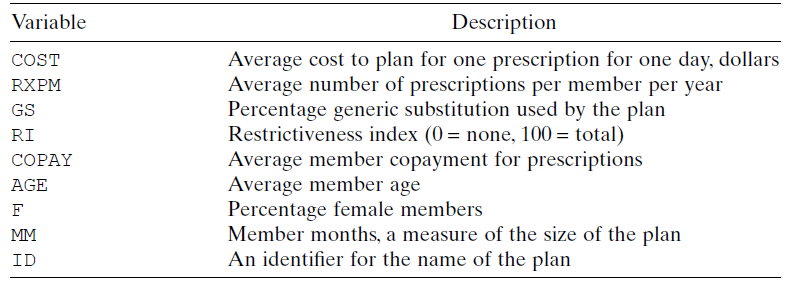

```r
drugs<-alr4::drugcost
```

## Explore

```r
library(dplyr)
library(skimr)

drugs %>%
  skim() %>%
  yank("numeric") %>%
  select(-hist)
```

**Variable type: numeric**

| skim_variable | n_missing | complete_rate | mean | sd | p0 | p25 | p50 | p75 | p100 |
| --- | --- | --- | --- | --- | --- | --- | --- | --- | --- |
| COST | 0 | 1 | 1.23 | 0.11 | 0.99 | 1.16 | 1.23 | 1.34 | 1.38 |
| RXPM | 0 | 1 | 5.97 | 1.68 | 2.80 | 5.20 | 6.10 | 7.00 | 10.70 |
| GS | 0 | 1 | 39.24 | 5.87 | 16.00 | 37.00 | 40.00 | 42.00 | 50.00 |
| RI | 0 | 1 | 15.70 | 12.72 | 0.30 | 7.00 | 12.90 | 21.30 | 45.60 |
| COPAY | 0 | 1 | 6.17 | 1.44 | 4.13 | 5.27 | 5.71 | 6.27 | 10.87 |
| AGE | 0 | 1 | 29.09 | 1.29 | 25.20 | 28.50 | 29.10 | 29.80 | 32.40 |
| F | 0 | 1 | 52.37 | 1.78 | 49.00 | 51.40 | 52.30 | 53.40 | 57.20 |
| MM | 0 | 1 | 410991.79 | 410180.68 | 491.00 | 73380.00 | 303312.00 | 591456.00 | 1388605.00 |

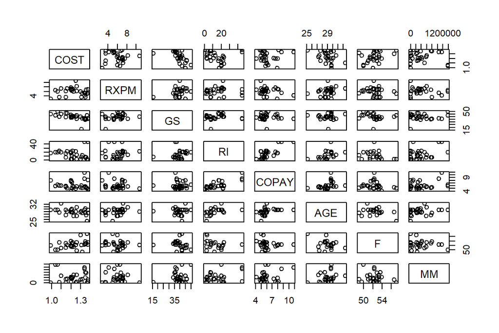

```r
plot(drugs)
```

# Model

```r
reg<-lm(COST ~ GS + AGE + RXPM + COPAY + AGE:COPAY, data=drugs)
```

# Test

```r
summary(reg)
```

```
##
## Call:
## lm(formula = COST ~ GS + AGE + RXPM + COPAY + AGE:COPAY, data = drugs)
##
## Residuals:
##       Min        1Q    Median        3Q       Max
## -0.128903 -0.057898  0.001658  0.040537  0.129144
##
## Coefficients:
##              Estimate Std. Error t value Pr(>|t|)
## (Intercept)  9.017319   4.473404   2.016 0.055653 .
## GS          -0.012221   0.002675  -4.568 0.000137 ***
## AGE         -0.255759   0.150646  -1.698 0.103048
## RXPM         0.021383   0.010134   2.110 0.045950 *
## COPAY       -1.145541   0.815828  -1.404 0.173635
## AGE:COPAY    0.039278   0.027535   1.426 0.167166
## ---
## Signif. codes:  0 '***' 0.001 '**' 0.01 '*' 0.05 '.' 0.1 ' ' 1
##
## Residual standard error: 0.07944 on 23 degrees of freedom
## Multiple R-squared:  0.5719, Adjusted R-squared:  0.4789
## F-statistic: 6.146 on 5 and 23 DF,  p-value: 0.000936
```

```r
car::Anova(reg, type = 2)
```

```
## Anova Table (Type II tests)
##
## Response: COST
##             Sum Sq Df F value    Pr(>F)
## GS        0.131682  1 20.8668 0.0001366 ***
## AGE       0.060661  1  9.6125 0.0050427 **
## RXPM      0.028094  1  4.4519 0.0459501 *
## COPAY     0.014668  1  2.3243 0.1409998
## AGE:COPAY 0.012841  1  2.0348 0.1671657
## Residuals 0.145143 23
## ---
## Signif. codes:  0 '***' 0.001 '**' 0.01 '*' 0.05 '.' 0.1 ' ' 1
```

```r
confint(reg, "RXPM")
```

```
##             2.5 %     97.5 %
## RXPM 0.0004183952 0.04234769
```